# Project: No-show appointments Data Analysis

- Introduction
- Data Wrangling
- Exploratory Data Analysis
- Conclusions

## Introduction

This dataset collects information from 100k medical appointments in Brazil and is focused on the question of whether or not patients show up for their appointment. The original source of the dataset is [Kaggle](https://www.kaggle.com/joniarroba/noshowappointments). A number of characteristics about the patient are included in each row.

There are **1 dependent variable** (No-show) and **13 independent variables** (PatientId, AppointmentID, Gender, ScheduledDay, AppointmentDay, Age, Neighbourhood, Scholarship, Hipertension, Diabetes, Alcoholism, Handcap, SMS_received).

### Description of the Dataset's Features:

- **PatientId**: A number to identify the patient.
- **AppointmentID**: A number to identify the appointment
- **Gender**: The gender of the patient. *M: Male or F: Female.*
- **ScheduledDay**: The date where the patient set up their appointment.
- **AppointmentDay**: The date of the appointment.
- **Age**: The age of the patient.
- **Neighbourhood**: The location of the hospital.
- **Scholarship**: An integer value that indicates whether or not the patient is enrolled in Brasilian welfare program Bolsa Família. *1: True or 0: False*
- **Hipertension**: A integer value that indicates whether or not the patient has hipertensión. *1: True or 0: False*
- **Diabetes**: A integer value that indicates whether or not the patient has diabetes. *1: True or 0: False*
- **Alcoholism**: A integer value that indicates whether or not the patient is alcoholic. *1: True or 0: False*
- **Handcap**: A number of disabilities the patient has.
- **SMS_received**: A integer value that indicates whether or not the patient received an SMS message. *1: True or 0: False*
- **No-show**: Indicates whether or not the patient showed up for their appointment. *‘No’: the patient showed up to their appointment or ‘Yes’: the patient did not show up.*

### Questions

- Do patients who are enrolled in the Brasilian welfare program Bolsa Família are more likely to show up for their scheduled appointment?
- Does the SMS messages affect the patients' attendance for their scheduled appointment?
- Which appointment month has the most not attended appointments rate?
- What is the most month that patients call to schedule their appointments?
- Which gender usually attends their scheduled appointment?
- Is there a relation between the number of disabilities and the patients not showing up to their scheduled appointment?
- Does the location of the hospital has an impact on patients not showing up for their scheduled appointment?
- What is the most disease that absent patients have?

```python
# Use this cell to set up import statements for all of the packages that you
#   plan to use.

# Remember to include a 'magic word' so that your visualizations are plotted
#   inline with the notebook. See this page for more:
#   http://ipython.readthedocs.io/en/stable/interactive/magics.html

import numpy as np
import pandas as pd
import matplotlib.pyplot as plt
import seaborn as sns
%matplotlib inline
```

## Data Wrangling

### General Properties

First, we will load the "No-Show Appointments" data and print out the first few rows.

```python
# Load the "No-Show Appointments" data and print out a few lines.
df = pd.read_csv('noshowappointments-kagglev2-may-2016.csv')
df.head()
```

|  | PatientId | AppointmentID | Gender | ScheduledDay | AppointmentDay | Age | Neighbourhood | Scholarship | Hipertension | Diabetes | Alcoholism | Handcap | SMS_received | No-show |
| --- | --- | --- | --- | --- | --- | --- | --- | --- | --- | --- | --- | --- | --- | --- |
| 0 | 2.987250e+13 | 5642903 | F | 2016-04-29T18:38:08Z | 2016-04-29T00:00:00Z | 62 | JARDIM DA PENHA | 0 | 1 | 0 | 0 | 0 | 0 | No |
| 1 | 5.589978e+14 | 5642503 | M | 2016-04-29T16:08:27Z | 2016-04-29T00:00:00Z | 56 | JARDIM DA PENHA | 0 | 0 | 0 | 0 | 0 | 0 | No |
| 2 | 4.262962e+12 | 5642549 | F | 2016-04-29T16:19:04Z | 2016-04-29T00:00:00Z | 62 | MATA DA PRAIA | 0 | 0 | 0 | 0 | 0 | 0 | No |
| 3 | 8.679512e+11 | 5642828 | F | 2016-04-29T17:29:31Z | 2016-04-29T00:00:00Z | 8 | PONTAL DE CAMBURI | 0 | 0 | 0 | 0 | 0 | 0 | No |
| 4 | 8.841186e+12 | 5642494 | F | 2016-04-29T16:07:23Z | 2016-04-29T00:00:00Z | 56 | JARDIM DA PENHA | 0 | 1 | 1 | 0 | 0 | 0 | No |

```python
# Print the dimensionality of the DataFrame.
df.shape
```

```
(110527, 14)
```

```python
# Use the describe() function to calculate some statistical data of the DataFrame.
df.describe()
```

|  | PatientId | AppointmentID | Age | Scholarship | Hipertension | Diabetes | Alcoholism | Handcap | SMS_received |
| --- | --- | --- | --- | --- | --- | --- | --- | --- | --- |
| count | 1.105270e+05 | 1.105270e+05 | 110527.000000 | 110527.000000 | 110527.000000 | 110527.000000 | 110527.000000 | 110527.000000 | 110527.000000 |
| mean | 1.474963e+14 | 5.675305e+06 | 37.088874 | 0.098266 | 0.197246 | 0.071865 | 0.030400 | 0.022248 | 0.321026 |
| std | 2.560949e+14 | 7.129575e+04 | 23.110205 | 0.297675 | 0.397921 | 0.258265 | 0.171686 | 0.161543 | 0.466873 |
| min | 3.921784e+04 | 5.030230e+06 | -1.000000 | 0.000000 | 0.000000 | 0.000000 | 0.000000 | 0.000000 | 0.000000 |
| 25% | 4.172614e+12 | 5.640286e+06 | 18.000000 | 0.000000 | 0.000000 | 0.000000 | 0.000000 | 0.000000 | 0.000000 |
| 50% | 3.173184e+13 | 5.680573e+06 | 37.000000 | 0.000000 | 0.000000 | 0.000000 | 0.000000 | 0.000000 | 0.000000 |
| 75% | 9.439172e+13 | 5.725524e+06 | 55.000000 | 0.000000 | 0.000000 | 0.000000 | 0.000000 | 0.000000 | 1.000000 |
| max | 9.999816e+14 | 5.790484e+06 | 115.000000 | 1.000000 | 1.000000 | 1.000000 | 1.000000 | 4.000000 | 1.000000 |

Scholarship, Hipertension, Diabetes, Alcoholism, SMS_received, and No-show variables shouldn't have statistical data, so they need be changed to boolean data type.

```python
# Use the info() function to print a concise summary of a DataFrame.
df.info()
```

```
<class 'pandas.core.frame.DataFrame'>
RangeIndex: 110527 entries, 0 to 110526
Data columns (total 14 columns):
 #   Column          Non-Null Count   Dtype
---  ------          --------------   -----
 0   PatientId       110527 non-null  float64
 1   AppointmentID   110527 non-null  int64
 2   Gender          110527 non-null  object
 3   ScheduledDay    110527 non-null  object
 4   AppointmentDay  110527 non-null  object
 5   Age             110527 non-null  int64
 6   Neighbourhood   110527 non-null  object
 7   Scholarship     110527 non-null  int64
 8   Hipertension    110527 non-null  int64
 9   Diabetes        110527 non-null  int64
 10  Alcoholism      110527 non-null  int64
 11  Handcap         110527 non-null  int64
 12  SMS_received    110527 non-null  int64
 13  No-show         110527 non-null  object
dtypes: float64(1), int64(8), object(5)
memory usage: 11.8+ MB
```

There are no null values.

```python
# Check if there are any duplicate rows.
df.duplicated().sum()
```

```
0
```

There are no duplicated rows.

```python
# Check how many unique elements in each variable.
df.nunique()
```

```
PatientId          62299
AppointmentID     110527
Gender                 2
ScheduledDay      103549
AppointmentDay        27
Age                  104
Neighbourhood         81
Scholarship            2
Hipertension           2
Diabetes               2
Alcoholism             2
Handcap                5
SMS_received           2
No-show                2
dtype: int64
```

Why the Handcap has 5 unique elements? Let's [list all the unique values.](https://chrisalbon.com/python/data_wrangling/pandas_list_unique_values_in_column/)

```python
# List the unique values in the Handcap column.
df['Handcap'].unique()
```

```
array([0, 1, 2, 3, 4], dtype=int64)
```

After some investigation, the dataset creator, Joni Hoppen, stated that the 'Handcap' refers to the number of disabilities a person has. For example, if the person is blind and can't walk, the total is 2. [(Here is the discussion)](https://www.kaggle.com/joniarroba/noshowappointments/discussion/29699)

```python
# Check if the age has negative values (invalid values)
df.query('Age < 0')
```

|  | PatientId | AppointmentID | Gender | ScheduledDay | AppointmentDay | Age | Neighbourhood | Scholarship | Hipertension | Diabetes | Alcoholism | Handcap | SMS_received | No-show |
| --- | --- | --- | --- | --- | --- | --- | --- | --- | --- | --- | --- | --- | --- | --- |
| 99832 | 4.659432e+14 | 5775010 | F | 2016-06-06T08:58:13Z | 2016-06-06T00:00:00Z | -1 | ROMÃO | 0 | 0 | 0 | 0 | 0 | 0 | No |

There are only one negative value.

### Observations:

- This dataset has no null data.
- This dataset has no duplicate rows.
- The Age variable has one negative value that needs to be dropped.
- Some data types need to be changed.
  - PatientId and AppointmentID need to be changed to a string, since they are an ID number (they have no numerical meaning).
  - ScheduledDay and AppointmentDay need to be changed to a date instead of strings.
  - Scholarship, Hipertension, Diabetes, Alcoholism, SMS_received, and No-show should be changed to boolean.

### Data Cleaning

Let's drop the row that contains invalid value (age = -1). [Reference](https://chrisalbon.com/python/data_wrangling/pandas_dropping_column_and_rows/)

```python
df.shape
```

```
(110527, 14)
```

```python
df = df[df.Age != -1]
```

```python
df.shape
```

```
(110526, 14)
```

```python
# Check if the age has negative values (invalid values)
df.query('Age < 0')
```

|  | PatientId | AppointmentID | Gender | ScheduledDay | AppointmentDay | Age | Neighbourhood | Scholarship | Hipertension | Diabetes | Alcoholism | Handcap | SMS_received | No-show |
| --- | --- | --- | --- | --- | --- | --- | --- | --- | --- | --- | --- | --- | --- | --- |

The row was deleted successfully.

Now, let's fix the datatypes, but first, let's drop the PatientId and AppointmentID variables since they won't affect the analysis and we don't need them.

```python
# Drop the not needed columns
df.drop(['PatientId', 'AppointmentID'], axis=1, inplace=True)
df.head()
```

|  | Gender | ScheduledDay | AppointmentDay | Age | Neighbourhood | Scholarship | Hipertension | Diabetes | Alcoholism | Handcap | SMS_received | No-show |
| --- | --- | --- | --- | --- | --- | --- | --- | --- | --- | --- | --- | --- |
| 0 | F | 2016-04-29T18:38:08Z | 2016-04-29T00:00:00Z | 62 | JARDIM DA PENHA | 0 | 1 | 0 | 0 | 0 | 0 | No |
| 1 | M | 2016-04-29T16:08:27Z | 2016-04-29T00:00:00Z | 56 | JARDIM DA PENHA | 0 | 0 | 0 | 0 | 0 | 0 | No |
| 2 | F | 2016-04-29T16:19:04Z | 2016-04-29T00:00:00Z | 62 | MATA DA PRAIA | 0 | 0 | 0 | 0 | 0 | 0 | No |
| 3 | F | 2016-04-29T17:29:31Z | 2016-04-29T00:00:00Z | 8 | PONTAL DE CAMBURI | 0 | 0 | 0 | 0 | 0 | 0 | No |
| 4 | F | 2016-04-29T16:07:23Z | 2016-04-29T00:00:00Z | 56 | JARDIM DA PENHA | 0 | 1 | 1 | 0 | 0 | 0 | No |

The PatientId and AppointmentID were dropped successfully.

Let's convert the integer values to boolean for Scholarship, Hipertension, Diabetes, Alcoholism, SMS_received variables. [Reference](https://oindrilasen.com/2019/08/convert-integer-to-boolean-and-vice-versa-in-pandas-dataframe/)

```python
# Convert "Scholarship, Hipertension, Diabetes, Alcoholism, and SMS_received" columns to Boolean
df.Scholarship = df.Scholarship.astype('bool')
df.Hipertension = df.Hipertension.astype('bool')
df.Diabetes = df.Diabetes.astype('bool')
df.Alcoholism = df.Alcoholism.astype('bool')
df.SMS_received = df.SMS_received.astype('bool')
df.dtypes
```

```
Gender            object
ScheduledDay      object
AppointmentDay    object
Age                int64
Neighbourhood     object
Scholarship         bool
Hipertension        bool
Diabetes            bool
Alcoholism          bool
Handcap            int64
SMS_received        bool
No-show           object
dtype: object
```

Now, let's convert the No-show datatype from string to boolean using the [replace() function.](https://pandas.pydata.org/pandas-docs/stable/reference/api/pandas.DataFrame.replace.html)

```python
# Create a dictionary to specify the boolean values for the Yes and No existing values.
show_column = {'Yes': True, 'No': False}

# Use replace() function
df["No-show"].replace(show_column, inplace=True)

# Check the datatypes now
df.dtypes
```

```
Gender            object
ScheduledDay      object
AppointmentDay    object
Age                int64
Neighbourhood     object
Scholarship         bool
Hipertension        bool
Diabetes            bool
Alcoholism          bool
Handcap            int64
SMS_received        bool
No-show             bool
dtype: object
```

The Scholarship, Hipertension, Diabetes, Alcoholism, SMS_received, and No-show variables were converted to boolean successfully.

Let's convert the ScheduledDay and AppointmentDay to datatime datatype using Pandas [to_datetime() function.](https://pandas.pydata.org/pandas-docs/stable/reference/api/pandas.to_datetime.html)

```python
df['ScheduledDay'] = pd.to_datetime(df['ScheduledDay'])
df['AppointmentDay'] = pd.to_datetime(df['AppointmentDay'])
```

```python
df.dtypes
```

```
Gender                         object
ScheduledDay      datetime64[ns, UTC]
AppointmentDay    datetime64[ns, UTC]
Age                             int64
Neighbourhood                  object
Scholarship                      bool
Hipertension                     bool
Diabetes                         bool
Alcoholism                       bool
Handcap                         int64
SMS_received                     bool
No-show                          bool
dtype: object
```

The ScheduledDay and AppointmentDay variables were converted to datatime datatype successfully.

```python
df.head()
```

|  | Gender | ScheduledDay | AppointmentDay | Age | Neighbourhood | Scholarship | Hipertension | Diabetes | Alcoholism | Handcap | SMS_received | No-show |
| --- | --- | --- | --- | --- | --- | --- | --- | --- | --- | --- | --- | --- |
| 0 | F | 2016-04-29 18:38:08+00:00 | 2016-04-29 00:00:00+00:00 | 62 | JARDIM DA PENHA | False | True | False | False | 0 | False | False |
| 1 | M | 2016-04-29 16:08:27+00:00 | 2016-04-29 00:00:00+00:00 | 56 | JARDIM DA PENHA | False | False | False | False | 0 | False | False |
| 2 | F | 2016-04-29 16:19:04+00:00 | 2016-04-29 00:00:00+00:00 | 62 | MATA DA PRAIA | False | False | False | False | 0 | False | False |
| 3 | F | 2016-04-29 17:29:31+00:00 | 2016-04-29 00:00:00+00:00 | 8 | PONTAL DE CAMBURI | False | False | False | False | 0 | False | False |
| 4 | F | 2016-04-29 16:07:23+00:00 | 2016-04-29 00:00:00+00:00 | 56 | JARDIM DA PENHA | False | True | True | False | 0 | False | False |

Now the dataset is clean and valid. It is ready to be explored, but first let's create masks for rows where the patients attended the appointment and rows where they didn't to help us in the exploration step.

```python
# save cleaned dataset
df.to_csv('noshowappointments-cleaned.csv', index=False)
```

```python
# Create masks for rows where the patients attended the appointment and rows where they didn't
attended = df['No-show'] == False
absent = df['No-show'] == True
```

## Exploratory Data Analysis

> **Tip**: Now that you've trimmed and cleaned your data, you're ready to move on to exploration. Compute statistics and create visualizations with the goal of addressing the research questions that you posed in the Introduction section. It is recommended that you be systematic with your approach. Look at one variable at a time, and then follow it up by looking at relationships between variables.

### Research Question 1: Do patients who enrolled in the Brasilian welfare program Bolsa Família are more likely to show up for their scheduled appointment?

To compare the two values, let's find the percentage of each. [Reference](https://stackoverflow.com/questions/50558458/pandas-get-frequency-of-item-occurrences-in-a-column-as-percentage)

```python
# Create masks for rows where the patients have scholarship and rows where they don't.
no_scholarship = df['Scholarship'] == False
have_scholarship = df['Scholarship'] == True
```

```python
# Find the attendance of patients who don't have a scholarship
no_scholarship_show = df['No-show'][no_scholarship].value_counts(normalize=True) * 100
no_scholarship_show
```

```
False    80.192645
True     19.807355
Name: No-show, dtype: float64
```

```python
# Find the attendance of patients who have a scholarship
have_scholarship_show = df['No-show'][have_scholarship].value_counts(normalize=True) * 100
have_scholarship_show
```

```
False    76.263696
True     23.736304
Name: No-show, dtype: float64
```

Now, let's compare them using matplotlib bar chart.

[figure not shown]

```python
ind = np.arange(len(no_scholarship_show))  # the x locations for the groups
width = 0.35       # the width of the bars

# plot bars
no_scholarship_bars = plt.bar(ind, no_scholarship_show, width, color='g', alpha=.7, label='Have Scholarship')
have_scholarship_bars = plt.bar(ind + width, have_scholarship_show, width, color='r', alpha=.7, label='No Scholarship')

# title and labels
plt.ylabel('Percentage')
plt.xlabel('Attendance')
plt.title('Percentage by Scholarship and Attendance')
locations = ind + width / 2  # xtick locations
labels = ['Attended', 'Absent']  # xtick labels
plt.xticks(locations, labels)

# legend
plt.legend();
```

### Research Question 2: Does the SMS messages affect the patients' attendance for their scheduled appointment?

To compare the two values, let's find the percentage of each. [Reference](https://stackoverflow.com/questions/50558458/pandas-get-frequency-of-item-occurrences-in-a-column-as-percentage)

```python
# Find the attended patients who received SMS and who did not
attended_SMS = df.SMS_received[attended].value_counts(normalize=True) * 100
attended_SMS
```

```
False    70.866258
True     29.133742
Name: SMS_received, dtype: float64
```

```python
# Find the absent patients who received SMS and who did not
absent_SMS = df.SMS_received[absent].value_counts(normalize=True) * 100
absent_SMS
```

```
False    56.162911
True     43.837089
Name: SMS_received, dtype: float64
```

Now, let's compare them using matplotlib bar chart.

[figure not shown]

```python
ind = np.arange(len(attended_SMS))  # the x locations for the groups
width = 0.35       # the width of the bars

# plot bars
attended_SMS_bars = plt.bar(ind, attended_SMS, width, color='g', alpha=.7, label='Attended')
absent_SMS_bars = plt.bar(ind + width, absent_SMS, width, color='r', alpha=.7, label='Absent')

# title and labels
plt.ylabel('Percentage')
plt.xlabel('SMS')
plt.title('Percentage by Attendance and Receiving SMS')
locations = ind + width / 2  # xtick locations
labels = ['Received', 'Did NOT receive']  # xtick labels
plt.xticks(locations, labels)

# legend
plt.legend();
```

### Research Question 3: Which appointment month has the most not attended appointments rate?

First, we will divide the data frame into two, one for patients who showed up for their scheduled appointment and one for patients who did not.

```python
# Create Data Frame for patients who showed up for their scheduled appointment.
attended_df = df[attended]
attended_df.shape
```

```
(88207, 12)
```

```python
# Create Data Frame for patients who did NOT show up for their scheduled appointment.
absent_df = df[absent]
absent_df.shape
```

```
(22319, 12)
```

Then, we need to use groupby() function to group months and count the appointments for each dataFrame. We will use Panda's Grouper class to group the dataframe using key and freq column. [Reference](https://kanoki.org/2020/05/26/dataframe-groupby-date-and-time/)

```python
# get counts for each month in attended_df
attended_months_count = attended_df.groupby(pd.Grouper(key='AppointmentDay',freq='M')).count()['Gender']
attended_months_count
```

```
AppointmentDay
2016-04-30 00:00:00+00:00     2602
2016-05-31 00:00:00+00:00    64037
2016-06-30 00:00:00+00:00    21568
Freq: M, Name: Gender, dtype: int64
```

```python
# get counts for each month in absent_df
absent_months_count = absent_df.groupby(pd.Grouper(key='AppointmentDay',freq='M')).count()['Gender']
absent_months_count
```

```
AppointmentDay
2016-04-30 00:00:00+00:00      633
2016-05-31 00:00:00+00:00    16804
2016-06-30 00:00:00+00:00     4882
Freq: M, Name: Gender, dtype: int64
```

```python
# get total counts for each month in attended_df
attended_months_totals = attended_df.count()['Gender']
attended_months_totals
```

```
88207
```

```python
# get total counts for each month in absent_df
absent_months_totals = absent_df.count()['Gender']
absent_months_totals
```

```
22319
```

```python
# get attended months percentage by dividing attended month count by total # of attended patients samples then multiplied by 100
attended_percentage = (attended_months_count / attended_months_totals) * 100
attended_percentage
```

```
AppointmentDay
2016-04-30 00:00:00+00:00     2.949879
2016-05-31 00:00:00+00:00    72.598547
2016-06-30 00:00:00+00:00    24.451574
Freq: M, Name: Gender, dtype: float64
```

```python
# get absent months percentage by dividing absent month counts by total # of absent patients samples then multiplied by 100
absent_percentage = (absent_months_count / absent_months_totals) * 100
absent_percentage
```

```
AppointmentDay
2016-04-30 00:00:00+00:00     2.836149
2016-05-31 00:00:00+00:00    75.290112
2016-06-30 00:00:00+00:00    21.873740
Freq: M, Name: Gender, dtype: float64
```

Now, let's compare the months using matplotlib bar chart.

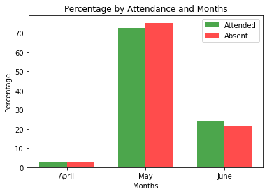

```python
#Set the x coordinate location for each month group and and width of each bar.
ind = np.arange(len(attended_months_count))  # the x locations for the groups
width = 0.35       # the width of the bars

# plot bars
attended_months_bars = plt.bar(ind, attended_percentage, width, color='g', alpha=.7, label='Attended')
absent_months_bars = plt.bar(ind + width, absent_percentage, width, color='r', alpha=.7, label='Absent')

# title and labels
plt.ylabel('Percentage')
plt.xlabel('Months')
plt.title('Percentage by Attendance and Months')
locations = ind + width / 2  # xtick locations
labels = ['April', 'May', 'June']  # xtick labels
plt.xticks(locations, labels)

# legend
plt.legend();
```

- May has the most appointments.
- April has the least appointments.
- The percentage of attended patients who have appointments in May is less than the absent patients who have appointments in May.
- The percentage of attended patients who have appointments in June is more than the absent patients who have appointments in June.
- The percentage of attended patients who have appointments in April is almost the same as the percentage of the absent patients who have appointments in April.

### Research Question 4: What is the most month that patients call to schedule their appointments?

First, we need to use groupby() function to group months and count the patients who set up their appointment for attended and absent data frames. We will use Panda's Grouper class to group the dataframe using key and freq column. [Reference](https://kanoki.org/2020/05/26/dataframe-groupby-date-and-time/)

```python
sc_months = df.groupby(pd.Grouper(key='ScheduledDay',freq='M')).count()['Gender']
sc_months
```

```
ScheduledDay
2015-11-30 00:00:00+00:00        1
2015-12-31 00:00:00+00:00       61
2016-01-31 00:00:00+00:00       60
2016-02-29 00:00:00+00:00      281
2016-03-31 00:00:00+00:00     3614
2016-04-30 00:00:00+00:00    25339
2016-05-31 00:00:00+00:00    67421
2016-06-30 00:00:00+00:00    13749
Freq: M, Name: Gender, dtype: int64
```

Let's visualize this data using matplotlip pie chart. [Reference](https://www.tutorialspoint.com/matplotlib/matplotlib_pie_chart.htm)

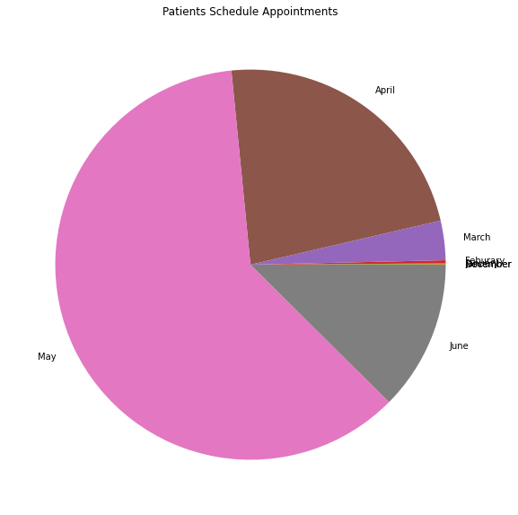

```python
index = ['November', 'December', 'January', 'Feburary', 'March', 'April', 'May', 'June']
sc_months.plot(kind='pie', ylabel='', title='Patients Schedule Appointments', figsize=(10,10), labels=index);
```

- May has the most calls from patients to schedule appointments.
- November has the least calls from patients to schedule appointments.

### Research Question 5: Which gender usually attends their scheduled appointment?

To compare the two genders, let's find the percentage of each. [Reference](https://stackoverflow.com/questions/50558458/pandas-get-frequency-of-item-occurrences-in-a-column-as-percentage)

```python
df.Gender[attended].value_counts(normalize=True) * 100
```

```
F    64.898477
M    35.101523
Name: Gender, dtype: float64
```

Let's visualize this data using matplotlip pie chart. [Reference](https://www.tutorialspoint.com/matplotlib/matplotlib_pie_chart.htm)

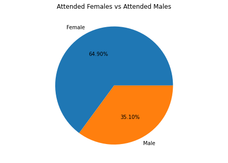

```python
fig = plt.figure()
ax = fig.add_axes([0,0,1,1])
ax.axis('equal')
gender = ['Female', 'Male']
percentages = [64.898477,35.1015232]
ax.pie(percentages, labels = gender,autopct='%1.2f%%')
plt.title('Attended Females vs Attended Males')
plt.show()
```

```python
df.Gender[absent].value_counts(normalize=True) * 100
```

```
F    65.388234
M    34.611766
Name: Gender, dtype: float64
```

Let's visualize this data using matplotlip pie chart. [Reference](https://www.tutorialspoint.com/matplotlib/matplotlib_pie_chart.htm)

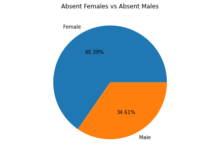

```python
fig = plt.figure()
ax = fig.add_axes([0,0,1,1])
ax.axis('equal')
gender = ['Female', 'Male']
percentages = [65.388234,34.611766]
ax.pie(percentages, labels = gender,autopct='%1.2f%%')
plt.title('Absent Females vs Absent Males')
plt.show()
```

### Research Question 6: Is there a relation between the number of disabilities and the patients not showing up to their scheduled appointment?

```python
# get counts for each handicap number in attended_df
attended_handcap_count = attended_df.groupby('Handcap').count()['Gender']
attended_handcap_count
```

```
Handcap
0    86373
1     1676
2      146
3       10
4        2
Name: Gender, dtype: int64
```

```python
# get counts for each handicap number in absent_df
absent_handcap_count = absent_df.groupby('Handcap').count()['Gender']
absent_handcap_count
```

```
Handcap
0    21912
1      366
2       37
3        3
4        1
Name: Gender, dtype: int64
```

```python
# get total counts for each handicap number in attended_df
attended_handcap_totals = attended_df.count()['Gender']
attended_handcap_totals
```

```
88207
```

```python
# get total counts for each handicap number in absent_df
absent_handcap_totals = absent_df.count()['Gender']
absent_handcap_totals
```

```
22319
```

```python
# get attended handicap number percentage by dividing attended handicap number count by total # of attended patients samples then multiplied by 100
attended_handcap_percentage = (attended_handcap_count / attended_handcap_totals) * 100
attended_handcap_percentage
```

```
Handcap
0    97.920800
1     1.900076
2     0.165520
3     0.011337
4     0.002267
Name: Gender, dtype: float64
```

```python
# get absent handicap number percentage by dividing absent handicap number counts by total # of absent patients samples then multiplied by 100
absent_handcap_percentage = (absent_handcap_count / absent_handcap_totals) * 100
absent_handcap_percentage
```

```
Handcap
0    98.176442
1     1.639858
2     0.165778
3     0.013441
4     0.004480
Name: Gender, dtype: float64
```

Now, let's compare the months using matplotlib bar chart.

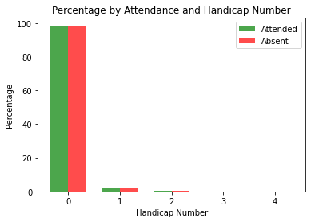

```python
#Set the x coordinate location for each month group and and width of each bar.
ind = np.arange(len(attended_handcap_count))  # the x locations for the groups
width = 0.35       # the width of the bars

# plot bars
attended_handcap_bars = plt.bar(ind, attended_handcap_percentage, width, color='g', alpha=.7, label='Attended')
absent_handcap_bars = plt.bar(ind + width, absent_handcap_percentage, width, color='r', alpha=.7, label='Absent')

# title and labels
plt.ylabel('Percentage')
plt.xlabel('Handicap Number')
plt.title('Percentage by Attendance and Handicap Number')
locations = ind + width / 2  # xtick locations
labels = ['0', '1', '2','3','4']  # xtick labels
plt.xticks(locations, labels)

# legend
plt.legend();
```

- There is NO relation between the number of disabilities and the patients not showing up to their scheduled appointment.

### Research Question 7: Does the location of the hospital has an impact on patients not showing up for their scheduled appointment?

First, count the occurence of each neighbourhood for patients who showed up for their scheduled appointment using Panda's [value_counts() function.](https://pandas.pydata.org/docs/reference/api/pandas.Series.value_counts.html) [Reference](https://stackoverflow.com/questions/20076195/what-is-the-most-efficient-way-of-counting-occurrences-in-pandas)

```python
df.Neighbourhood[attended].value_counts()
```

```
JARDIM CAMBURI       6252
MARIA ORTIZ          4586
RESISTÊNCIA          3525
JARDIM DA PENHA      3246
SANTA MARTHA         2635
                     ...
PONTAL DE CAMBURI      57
ILHA DO BOI            32
ILHA DO FRADE           8
AEROPORTO               7
PARQUE INDUSTRIAL       1
Name: Neighbourhood, Length: 80, dtype: int64
```

Let's visualize this data using matplotlib bar chart.

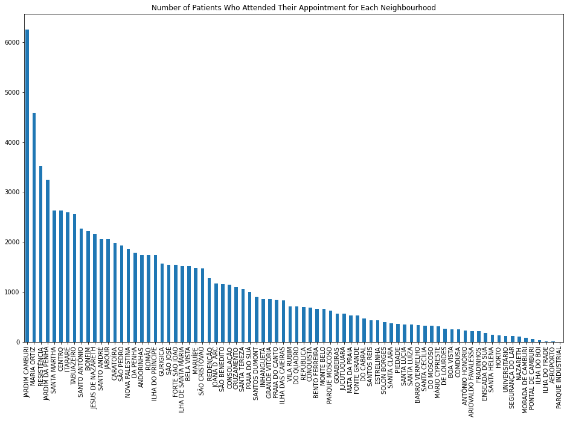

```python
(df.Neighbourhood[attended].value_counts()).plot(kind='bar', title='Number of Patients Who Attended Their Appointment for Each Neighbourhood', figsize=(16,10));
```

Then, count the occurence of each neighbourhood for patients who didn't show up for their scheduled appointment.

```python
df.Neighbourhood[absent].value_counts()
```

```
JARDIM CAMBURI                 1465
MARIA ORTIZ                    1219
ITARARÉ                         923
RESISTÊNCIA                     906
CENTRO                          703
                               ...
PONTAL DE CAMBURI                12
ILHA DO BOI                       3
ILHA DO FRADE                     2
ILHAS OCEÂNICAS DE TRINDADE       2
AEROPORTO                         1
Name: Neighbourhood, Length: 80, dtype: int64
```

Let's visualize this data using matplotlib bar chart.

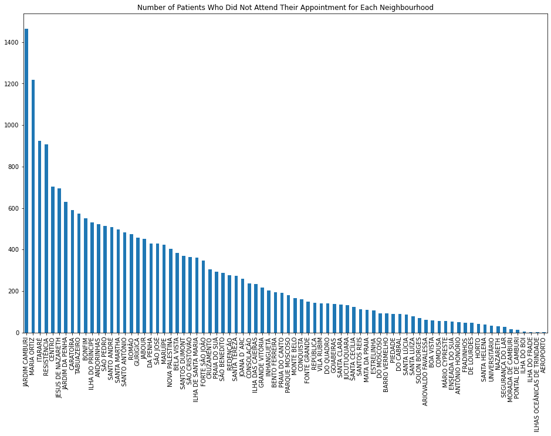

```python
(df.Neighbourhood[absent].value_counts()).plot(kind='bar', title='Number of Patients Who Did Not Attend Their Appointment for Each Neighbourhood', figsize=(16,10));
```

To see if the location of the hospital has an impact on patients not showing up for their scheduled appointment, we need to calculate the percentage change between the attended patient and the asbsent ones.

I found that there's a Panda's function to calculate the percentage change [pct_change()](https://pandas.pydata.org/pandas-docs/stable/reference/api/pandas.DataFrame.pct_change.html) but it doesn't work if I want to compare two specific different columns, so I looked up this issue and found a solution in [StackOverflow by using a user-defined funtion.](https://stackoverflow.com/questions/42100058/percentage-difference-between-any-two-columns-of-pandas-dataframe)

```python
# The function below calculates the percentage change of two different columns.
# Reference: https://stackoverflow.com/questions/42100058/percentage-difference-between-any-two-columns-of-pandas-dataframe
def percentage_change(col1,col2):
    return ((col2 - col1) / col1) * 100

# Call the function to calculate the percentage difference between the attended neighbourhoods and the absent neighbourhoods.
percentage_change(df.Neighbourhood[attended].value_counts(normalize=True) * 100,df.Neighbourhood[absent].value_counts(normalize=True) * 100)
```

```
AEROPORTO             -43.541377
ANDORINHAS             18.268005
ANTÔNIO HONÓRIO       -10.585892
ARIOVALDO FAVALESSA    11.377465
BARRO VERMELHO          8.325731
                         ...
SÃO JOSÉ                9.199505
SÃO PEDRO               5.294017
TABUAZEIRO            -11.506239
UNIVERSITÁRIO           5.389429
VILA RUBIM            -21.514563
Name: Neighbourhood, Length: 81, dtype: float64
```

Let's visualize this data using matplotlib bar chart.

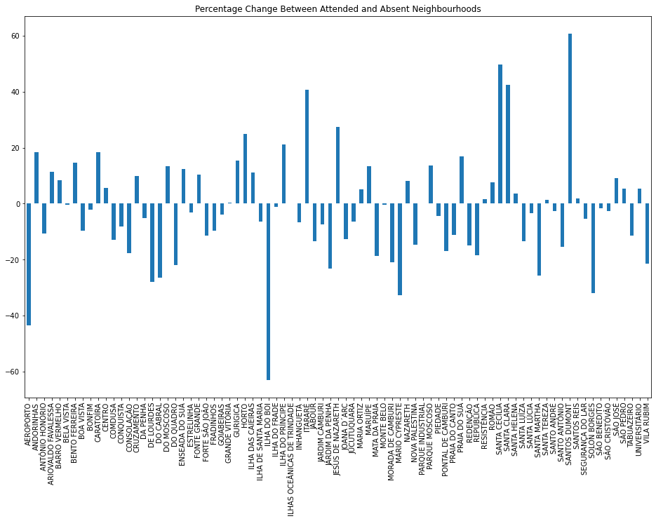

```python
(percentage_change(df.Neighbourhood[attended].value_counts(normalize=True),df.Neighbourhood[absent].value_counts(normalize=True))).plot(kind='bar', title='Percentage Change Between Attended and Absent Neighbourhoods', figsize=(16,10));
```

### Research Question 8: What is the most disease that absent patients have?

```python
# get counts for each patient who has hipertension or not in attended_df
attended_hipertension_count = attended_df.groupby('Hipertension').count()['Gender']
attended_hipertension_count
```

```
Hipertension
False    70178
True     18029
Name: Gender, dtype: int64
```

```python
# get counts for each patient who has hipertension or not in absent_df
absent_hipertension_count = absent_df.groupby('Hipertension').count()['Gender']
absent_hipertension_count
```

```
Hipertension
False    18547
True      3772
Name: Gender, dtype: int64
```

```python
# get counts for each patient who has diabetes or not in attended_df
attended_diabetes_count = attended_df.groupby('Diabetes').count()['Gender']
attended_diabetes_count
```

```
Diabetes
False    81694
True      6513
Name: Gender, dtype: int64
```

```python
# get counts for each patient who has diabetes or not in absent_df
absent_diabetes_count = absent_df.groupby('Diabetes').count()['Gender']
absent_diabetes_count
```

```
Diabetes
False    20889
True      1430
Name: Gender, dtype: int64
```

```python
# get counts for each patient who is alcoholic or not in attended_df
attended_alcoholism_count = attended_df.groupby('Alcoholism').count()['Gender']
attended_alcoholism_count
```

```
Alcoholism
False    85524
True      2683
Name: Gender, dtype: int64
```

```python
# get counts for each patient who is alcoholic or not in absent_df
absent_alcoholism_count = absent_df.groupby('Alcoholism').count()['Gender']
absent_alcoholism_count
```

```
Alcoholism
False    21642
True       677
Name: Gender, dtype: int64
```

```python
# get total counts for patients in attended_df
attended_totals = attended_df.count()['Gender']
attended_totals
```

```
88207
```

```python
# get total counts for patients in absent_df
absent_totals = absent_df.count()['Gender']
absent_totals
```

```
22319
```

```python
# get attended patient (hipertension) percentage by dividing attended hipertension count by total # of attended patients samples then multiplied by 100
attended_hipertension_percentage = (attended_hipertension_count / attended_totals) * 100
attended_hipertension_percentage
```

```
Hipertension
False    79.560579
True     20.439421
Name: Gender, dtype: float64
```

```python
# get absent patient (hipertension) percentage by dividing absent hipertension counts by total # of absent patients samples then multiplied by 100
absent_hipertension_percentage = (absent_hipertension_count / absent_totals) * 100
absent_hipertension_percentage
```

```
Hipertension
False    83.099601
True     16.900399
Name: Gender, dtype: float64
```

```python
# get attended patient (diabetes) percentage by dividing attended diabetes count by total # of attended patients samples then multiplied by 100
attended_diabetes_percentage = (attended_diabetes_count / attended_totals) * 100
attended_diabetes_percentage
```

```
Diabetes
False    92.616232
True      7.383768
Name: Gender, dtype: float64
```

```python
# get absent patient (diabetes) months percentage by dividing absent diabetes counts by total # of absent patients samples then multiplied by 100
absent_diabetes_percentage = (absent_diabetes_count / absent_totals) * 100
absent_diabetes_percentage
```

```
Diabetes
False    93.592903
True      6.407097
Name: Gender, dtype: float64
```

```python
# get attended patient (alcoholism) percentage by dividing attended alcoholism count by total # of attended patients samples then multiplied by 100
attended_alcoholism_percentage = (attended_alcoholism_count / attended_totals) * 100
attended_alcoholism_percentage
```

```
Alcoholism
False    96.958291
True      3.041709
Name: Gender, dtype: float64
```

```python
# get absent patient (alcoholism) percentage by dividing absent alcoholism counts by total # of absent patients samples then multiplied by 100
absent_alcoholism_percentage = (absent_alcoholism_count / absent_totals) * 100
absent_alcoholism_percentage
```

```
Alcoholism
False    96.96671
True      3.03329
Name: Gender, dtype: float64
```

Now, let's compare the months using matplotlib bar chart.

[figure not shown]

```python
#Set the x coordinate location for each month group and and width of each bar.
ind = np.arange(len(absent_hipertension_percentage))  # the x locations for the groups
width = 0.35       # the width of the bars

# plot bars
attended_hipertension_bars = plt.bar(ind, attended_hipertension_percentage, width, color='g', alpha=.7, label='Attended')
absent_hipertension_bars = plt.bar(ind + width, absent_hipertension_percentage, width, color='r', alpha=.7, label='Absent')



# title and labels
plt.ylabel('Percentage')
plt.xlabel('Hipertension')
plt.title('Percentage by Attendance and Hipertension')
locations = ind + width / 2  # xtick locations
labels = ['Has Hipertension', 'No Hipertension']  # xtick labels
plt.xticks(locations, labels)

# legend
plt.legend();
```

[figure not shown]

```python
#Set the x coordinate location for each month group and and width of each bar.
ind = np.arange(len(absent_diabetes_percentage))  # the x locations for the groups
width = 0.4       # the width of the bars

# plot bars
attended_diabetes_bars = plt.bar(ind, attended_diabetes_percentage, width, color='g', alpha=.7, label='Attended')
absent_diabetes_bars = plt.bar(ind + width, absent_diabetes_percentage, width, color='r', alpha=.7, label='Absent')


# title and labels
plt.ylabel('Percentage')
plt.xlabel('Diabetes')
plt.title('Percentage by Attendance and Diabetes')
locations = ind + width / 2  # xtick locations
labels = ['Has Diabetes', 'No Diabetes']  # xtick labels
plt.xticks(locations, labels)

# legend
plt.legend();
```

[figure not shown]

```python
#Set the x coordinate location for each month group and and width of each bar.
ind = np.arange(len(absent_alcoholism_percentage))  # the x locations for the groups
width = 0.4       # the width of the bars

# plot bars
attended_alcoholism_bars = plt.bar(ind, attended_alcoholism_percentage, width, color='g', alpha=.7, label='Attended')
absent_alcoholism_bars = plt.bar(ind + width, absent_alcoholism_percentage, width, color='r', alpha=.7, label='Absent')


# title and labels
plt.ylabel('Percentage')
plt.xlabel('Alcoholism')
plt.title('Percentage by Attendance and Alcoholism')
locations = ind + width / 2  # xtick locations
labels = ['Alcoholic', 'Non Alcoholic']  # xtick labels
plt.xticks(locations, labels)

# legend
plt.legend();
```

- The percentage of attended alcoholic patients is almost the same as the percentage of absent alcoholic patients.
- The percentage of attended non-alcoholic patients is almost the same as the percentage of absent non-alcoholic patients.

## Conclusions

**What is the most month that patients call to schedule their appointments?**

- Patients tend to contact hospitals to schedule an appointment in May more than other months, which is the same day as their actual appointment.

**Is there a relation between the number of disabilities and the patients not showing up to their scheduled appointment?**

- There is no relation between the number of disabilities and the patients not showing up to their scheduled appointment, however; patients with no disabilities are more likely to schedule an appointment.